# Data Manipulation

Mohammed alJaser

# 1 Introduction

*dplyr* is one of the most popular and most useful packages in the R-universe. It covers all aspects of data manipulation: filtering, selection, sorting and many more.

- Objectives: data manipulation with *dplyr*
- Requirements: none

# 2 Packages

We will analyse baby names from package *babynames*. Please make sure you have installed it before trying to load it. The same holds for *dplyr*.

- *babynames*: includes data for this tutorial
- *dplyr*: includes all data manipulation

```r
# install.packages("babynames")
library(babynames)  # data for this tutorial
library(dplyr)  # data manipulation
```

```r
library(ggplot2)  # visualisation of results
```

# 3 Data Preparation

```r
data("babynames")
glimpse(babynames)
```

```
## Observations: 1,924,665
## Variables: 5
## $ year <dbl> 1880, 1880, 1880, 1880, 1880, 1880, 1880, 1880, 1880, 1880, 18...
## $ sex  <chr> "F", "F", "F", "F", "F", "F", "F", "F", "F", "F", "F", "F", "F...
## $ name <chr> "Mary", "Anna", "Emma", "Elizabeth", "Minnie", "Margaret", "Id...
## $ n    <int> 7065, 2604, 2003, 1939, 1746, 1578, 1472, 1414, 1320, 1288, 12...
## $ prop <dbl> 0.07238359, 0.02667896, 0.02052149, 0.01986579, 0.01788843, 0....
```

There are five columns: *year*, *sex*, *name*, a count *n*, and corresponding proportion *prop*.

## 3.1 Filtering

```r
most_popular_female <- babynames %>%
    filter (year == 2014)
```

We have a dataframe with all names, but only from 2014. For the remainder we will always use piping where applicable.

We also have to filter for sex, so add an additional filter.

```r
most_popular_female <- babynames %>%
    filter (year == 2014) %>%
    filter (sex == "F")
```

Hint: some identical function names are part of other packages as well, e.g. *filter* and might be masked by them. This means if you just call *filter* the filter function from a different package is used instead of *dplyr*. Of course this does not work. Some workarounds: make sure that only *dplyr* is loaded; make sure *dplyr* is loaded before the other packages with identical function names. Another option to avoid trouble is to specifically define *filter* function from *dplyr* package by stating *dplyr::filter()*.

## 3.2 Sorting

Data can be sorted with *arrange*. This function can have several sorting columns. Default-order is ascending. If descending is required, it can be done with *desc()*.

In our example data is sorted according to *sex* and descending proportion *prop*.

```r
most_popular_female <- babynames %>%
    filter (year == 2014) %>%
    filter (sex == "F") %>%
    arrange (sex, desc(prop))
```

## 3.3 Column Selection

Often, not all columns are needed for further analysis. *select* can be applied to reduce number of columns. It can be done by defining columns to be kept or by defining columns to be excluded.

In our example only *name* is kept. An alternative would have been *select(-year, -sex, -n, -prop)*.

```r
most_popular_female <- babynames %>%
    filter (year == 2014) %>%
    filter (sex == "F") %>%
    arrange (sex, desc(prop)) %>%
    select (name)
```

Only the Top5 will be analysed. So at the end *head* is applied.

```r
most_popular_female <- babynames %>%
    filter (year == 2014) %>%
    filter (sex == "F") %>%
    arrange (sex, desc(prop)) %>%
    select (name) %>%
    head( n = 5)
as.character(most_popular_female$name)
```

```
## [1] "Emma"     "Olivia"   "Sophia"   "Isabella" "Ava"
```

These are in decreasing order the most famous girlnames of 2014.

## 3.4 Plot Results

Now, the development of these names should be shown. Original dataframe is filtered for these names. Function *mutate* can create new variables.

```r
babies_to_plot <- babynames %>%
    filter (sex == "F") %>%
    mutate (prop = prop * 100) %>%
    filter (name %in% most_popular_female$name)
```

Plot is created with *ggplot*. It shows Top5 names of 2014 and their development since 1880.

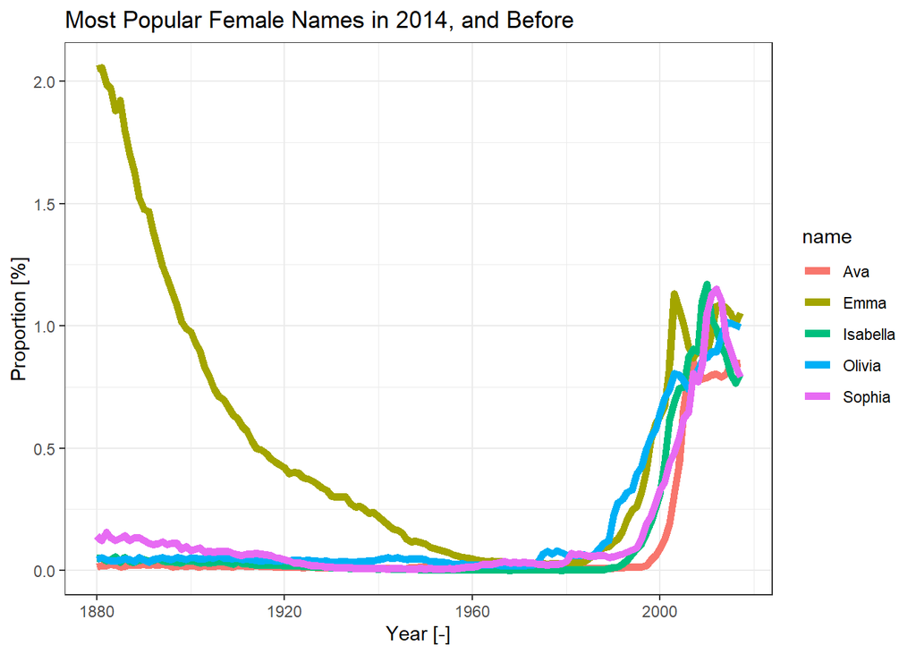

```r
ggplot(babies_to_plot, aes(year, prop, color = name)) +
    geom_line(size = 2) +
    xlab ("Year [-]") +
    ylab ("Proportion [%]") +
    ggtitle ("Most Popular Female Names in 2014, and Before") +
    theme_bw()
```

Emma was very famous in 1880 and following decades and only recently experienced a revival. The other Top5 names got famous only recently.

# 4 Conclusion

We learned *dplyr* package and some of its very important functions. There is more to discover. For a quick overview take a look at “Data Manipulation with dplyr, tidyr” cheatsheet (Help –> Cheatsheets).